# Assignment 7

Nicholas Irons [njirons@uw.edu]

2022-02-25

# Question 1: generate data frame

First we load in the full dataset.

```r
# download and unzip the larger data set
myUrl <- "http://staff.washington.edu/phurvitz/csde502_winter_2021/data/21600-0001-Data.dta.zip"

# zip file in $temp -- basename gets just the file name from the URL and not the URL path;
#   file.path stitches the tempdir() path to the file name
mytempdir <- tempdir()
zipfile <- file.path(mytempdir, basename(myUrl))

# dta file in $temp
dtafile <- tools::file_path_sans_ext(zipfile)

# check if the dta file exists
if (!file.exists(dtafile)) {
    # if the dta file doesn't exist, check for the zip file
    # check if the zip file exists, download if necessary
    if (!file.exists(zipfile)) {
        curl::curl_download(url = myUrl, destfile = zipfile)
    }
    # unzip the downloaded zip file
    if (file.exists(zipfile)) {
        unzip(zipfile = zipfile, exdir = mytempdir)
    }
}

# if the data set has not been read, read it in
if (!exists("ahcomplete")) {
    ahcomplete <- haven::read_dta(dtafile)
}
```

Now we select 4 columns: Hispanic origin, Asian race, language spoken at home, born in the United States.

```r
# select columns
df <- ahcomplete %>%
    select(
        hispanic = H1GI4,
        asian = H1GI6D,
        language = H1GI10,
        us_born = H1GI11
    )

# set label attribute for data frame
attributes(df)$label <- "Add Health questions: Hispanic origin, Asian race, language spoken at home, born in the US"

# create the factor variables with labels
# hispanic
hispanic_levels <- df$hispanic %>%
    attributes() %>%
    extract2("labels") %>%
    names()

df$hispanic <- factor(df$hispanic,labels = hispanic_levels)

# asian
asian_levels <- df$asian %>%
    attributes() %>%
    extract2("labels") %>%
    names()

df$asian <- factor(df$asian,labels = asian_levels)

# home language
language_levels <- df$language %>%
    attributes() %>%
    extract2("labels") %>%
    names()

df$language <- factor(df$language,labels = language_levels)

# us_born
us_born_levels <- df$us_born %>%
    attributes() %>%
    extract2("labels") %>%
    names()

df$us_born <- factor(df$us_born,labels = us_born_levels)

# set label attributes for columns
attributes(df$hispanic)$label <- "ARE YOU OF HISPANIC ORIGIN?"
attributes(df$asian)$label <- "RACE-ASIAN?"
attributes(df$language)$label <- "LANGUAGE SPOKEN AT HOME"
attributes(df$us_born)$label <- "BORN IN THE UNITED STATES?"
```

# Question 2: save data frame as RDS

Save the data frame as an RDS file:

```r
saveRDS(object = df, file = file.path(mytempdir, "hw7_df.RDS"))
```

# Question 3: create frequency tables

Create frequency tables from each variable:

```r
# hispanic
df %>%
    group_by(hispanic) %>%
    summarise(n = n()) %>%
    mutate(`%` = n / sum(n) * 100) %>%
    mutate(`%` = `%` %>% round(1)) %>%
    kable() %>%
    kable_styling(
        full_width = FALSE, position = "left",
        bootstrap_options = c("striped", "hover", "condensed", "responsive")
    )
```

hispanic

n

%

0. No

5738

88.2

1. Yes

743

11.4

6. Refused (skip to Q.6)

3

0.0

8. Don’t know (skip to Q.6)

20

0.3

*Table 1: Count and percent by Hispanic origin.*

```r
# asian
df %>%
    group_by(asian) %>%
    summarise(n = n()) %>%
    mutate(`%` = n / sum(n) * 100) %>%
    mutate(`%` = `%` %>% round(1)) %>%
    kable() %>%
    kable_styling(
        full_width = FALSE, position = "left",
        bootstrap_options = c("striped", "hover", "condensed", "responsive")
    )
```

asian

n

%

0. Not marked (skip to Q.8)

6215

95.6

1. Marked (If Asian/Pacific Islander among R’s answer ask Q

270

4.2

6. Refused (skip to Q.8)

4

0.1

8. Don’t know (skip to Q.8)

15

0.2

*Table 2: Count and percent by Asian race.*

```r
# language
df %>%
    group_by(language) %>%
    summarise(n = n()) %>%
    mutate(`%` = n / sum(n) * 100) %>%
    mutate(`%` = `%` %>% round(1)) %>%
    kable() %>%
    kable_styling(
        full_width = FALSE, position = "left",
        bootstrap_options = c("striped", "hover", "condensed", "responsive")
    )
```

language

n

%

1. English

6046

93.0

2. Spanish

314

4.8

3. Other

141

2.2

6. Refused

1

0.0

8. Don’t know

2

0.0

*Table 3: Count and percent by language spoken at home.*

```r
# us_born
df %>%
    group_by(us_born) %>%
    summarise(n = n()) %>%
    mutate(`%` = n / sum(n) * 100) %>%
    mutate(`%` = `%` %>% round(1)) %>%
    kable() %>%
    kable_styling(
        full_width = FALSE, position = "left",
        bootstrap_options = c("striped", "hover", "condensed", "responsive")
    )
```

us_born

n

%

0. No

399

6.1

1. Yes (skip to Q.15)

4807

73.9

6. Refused (skip to Q.15)

2

0.0

7. Legitimate skip (lived at current address since birth)

1293

19.9

8. Don’t know (skip to Q.15)

3

0.0

*Table 4: Count and percent by US born.*

Create a frequency tables from two variables:

```r
# hispanic x home language
df %>%
    group_by(hispanic, language) %>%
    summarise(n = n(), .groups = "drop_last") %>%
    mutate(`%` = n / sum(n) * 100) %>%
    mutate(`%` = `%` %>% round(1)) %>%
    kable() %>%
    kable_styling(
        full_width = FALSE, position = "left",
        bootstrap_options = c("striped", "hover", "condensed", "responsive")
    )
```

hispanic

language

n

%

0. No
1. English

5603

97.6

0. No
2. Spanish

6

0.1

0. No
3. Other

128

2.2

0. No
8. Don’t know

1

0.0

1. Yes
1. English

423

56.9

1. Yes
2. Spanish

308

41.5

1. Yes
3. Other

12

1.6

6. Refused (skip to Q.6)
1. English

2

66.7

6. Refused (skip to Q.6)
6. Refused

1

33.3

8. Don’t know (skip to Q.6)
1. English

18

90.0

8. Don’t know (skip to Q.6)
3. Other

1

5.0

8. Don’t know (skip to Q.6)
8. Don’t know

1

5.0

*Table 5: Count and percent of language spoken at home by Hispanic origin.*

```r
# home language x hispanic
df %>%
    group_by(language, hispanic) %>%
    summarise(n = n(), .groups = "drop_last") %>%
    mutate(`%` = n / sum(n) * 100) %>%
    mutate(`%` = `%` %>% round(1)) %>%
    kable() %>%
    kable_styling(
        full_width = FALSE, position = "left",
        bootstrap_options = c("striped", "hover", "condensed", "responsive")
    )
```

language

hispanic

n

%

1. English
0. No

5603

92.7

1. English
1. Yes

423

7.0

1. English
6. Refused (skip to Q.6)

2

0.0

1. English
8. Don’t know (skip to Q.6)

18

0.3

2. Spanish
0. No

6

1.9

2. Spanish
1. Yes

308

98.1

3. Other
0. No

128

90.8

3. Other
1. Yes

12

8.5

3. Other
8. Don’t know (skip to Q.6)

1

0.7

6. Refused
6. Refused (skip to Q.6)

1

100.0

8. Don’t know
0. No

1

50.0

8. Don’t know
8. Don’t know (skip to Q.6)

1

50.0

*Table 6: Count and percent of Hispanic origin by language spoken at home.*

# Question 4: create a graph

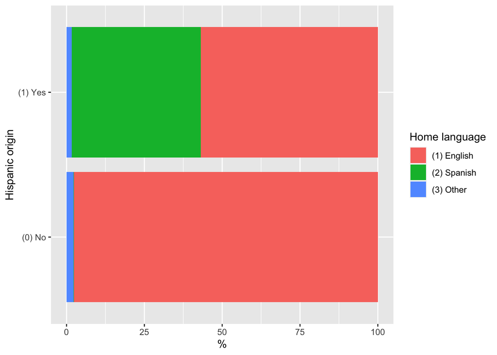

```r
hispanic_language <- df %>%
    group_by(
        hispanic,
        language
    ) %>%
    summarise(n = n(), .groups = "drop_last") %>%
    mutate(`%` = n / sum(n) * 100) %>%
    filter(!str_detect(hispanic, regex("refused|know", ignore_case = TRUE)),
           !str_detect(language, regex("refused|know", ignore_case = TRUE)))

ggplot(data = hispanic_language, mapping = aes(x = hispanic, y = `%`, fill = language)) +
    geom_bar(stat = "identity") +
    coord_flip() +
    scale_fill_discrete(name = "Home language") +
    xlab("Hispanic origin")
```

*Figure 1: Bar graph of percent language spoken at home by Hispanic origin.*

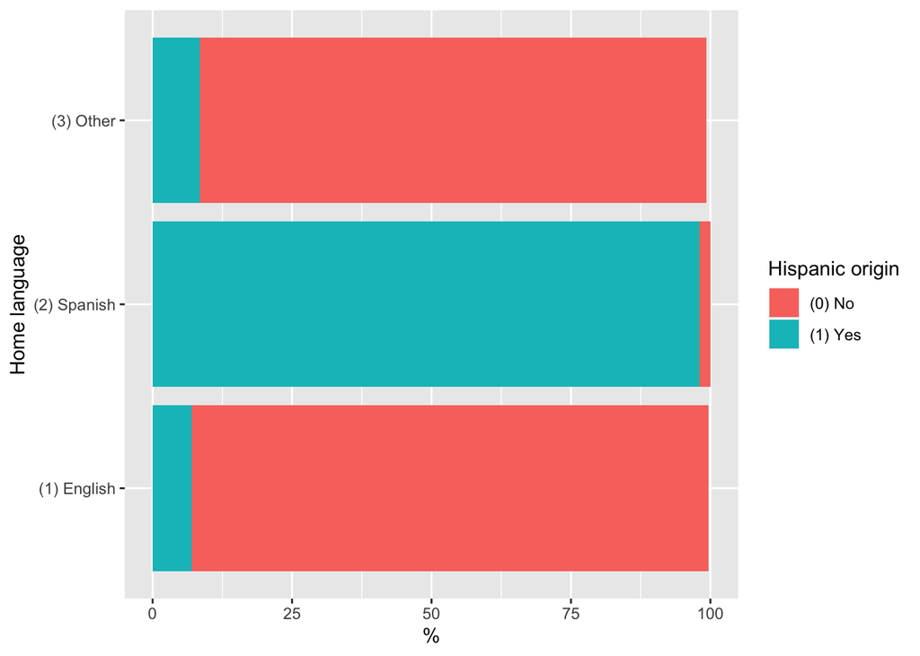

```r
language_hispanic <- df %>%
    group_by(
        language,
        hispanic
    ) %>%
    summarise(n = n(), .groups = "drop_last") %>%
    mutate(`%` = n / sum(n) * 100) %>%
    filter(!str_detect(hispanic, regex("refused|know", ignore_case = TRUE)),
           !str_detect(language, regex("refused|know", ignore_case = TRUE)))

ggplot(data = language_hispanic, mapping = aes(x = language, y = `%`, fill = hispanic)) +
    geom_bar(stat = "identity") +
    coord_flip() +
    scale_fill_discrete(name = "Hispanic origin") +
    xlab("Home language")
```

*Figure 2: Bar graph of Hispanic origin by percent language spoken at home.*

### Source code for this document

```r
knitr::opts_chunk$set(echo = TRUE)

pacman::p_load(
    tidyverse,
    magrittr,
    knitr,
    kableExtra,
    readstata13,
    haven,
    pdftools,
    curl,
    ggplot2,
    captioner
)

table_nums <- captioner(prefix = "Table")
figure_nums <- captioner(prefix = "Figure")
# download and unzip the larger data set
myUrl <- "http://staff.washington.edu/phurvitz/csde502_winter_2021/data/21600-0001-Data.dta.zip"

# zip file in $temp -- basename gets just the file name from the URL and not the URL path;
#   file.path stitches the tempdir() path to the file name
mytempdir <- tempdir()
zipfile <- file.path(mytempdir, basename(myUrl))

# dta file in $temp
dtafile <- tools::file_path_sans_ext(zipfile)

# check if the dta file exists
if (!file.exists(dtafile)) {
    # if the dta file doesn't exist, check for the zip file
    # check if the zip file exists, download if necessary
    if (!file.exists(zipfile)) {
        curl::curl_download(url = myUrl, destfile = zipfile)
    }
    # unzip the downloaded zip file
    if (file.exists(zipfile)) {
        unzip(zipfile = zipfile, exdir = mytempdir)
    }
}

# if the data set has not been read, read it in
if (!exists("ahcomplete")) {
    ahcomplete <- haven::read_dta(dtafile)
}
# select columns
df <- ahcomplete %>%
    select(
        hispanic = H1GI4,
        asian = H1GI6D,
        language = H1GI10,
        us_born = H1GI11
    )

# set label attribute for data frame
attributes(df)$label <- "Add Health questions: Hispanic origin, Asian race, language spoken at home, born in the US"

# create the factor variables with labels
# hispanic
hispanic_levels <- df$hispanic %>%
    attributes() %>%
    extract2("labels") %>%
    names()

df$hispanic <- factor(df$hispanic,labels = hispanic_levels)

# asian
asian_levels <- df$asian %>%
    attributes() %>%
    extract2("labels") %>%
    names()

df$asian <- factor(df$asian,labels = asian_levels)

# home language
language_levels <- df$language %>%
    attributes() %>%
    extract2("labels") %>%
    names()

df$language <- factor(df$language,labels = language_levels)

# us_born
us_born_levels <- df$us_born %>%
    attributes() %>%
    extract2("labels") %>%
    names()

df$us_born <- factor(df$us_born,labels = us_born_levels)

# set label attributes for columns
attributes(df$hispanic)$label <- "ARE YOU OF HISPANIC ORIGIN?"
attributes(df$asian)$label <- "RACE-ASIAN?"
attributes(df$language)$label <- "LANGUAGE SPOKEN AT HOME"
attributes(df$us_born)$label <- "BORN IN THE UNITED STATES?"
saveRDS(object = df, file = file.path(mytempdir, "hw7_df.RDS"))
# hispanic
df %>%
    group_by(hispanic) %>%
    summarise(n = n()) %>%
    mutate(`%` = n / sum(n) * 100) %>%
    mutate(`%` = `%` %>% round(1)) %>%
    kable() %>%
    kable_styling(
        full_width = FALSE, position = "left",
        bootstrap_options = c("striped", "hover", "condensed", "responsive")
    )
# asian
df %>%
    group_by(asian) %>%
    summarise(n = n()) %>%
    mutate(`%` = n / sum(n) * 100) %>%
    mutate(`%` = `%` %>% round(1)) %>%
    kable() %>%
    kable_styling(
        full_width = FALSE, position = "left",
        bootstrap_options = c("striped", "hover", "condensed", "responsive")
    )
# language
df %>%
    group_by(language) %>%
    summarise(n = n()) %>%
    mutate(`%` = n / sum(n) * 100) %>%
    mutate(`%` = `%` %>% round(1)) %>%
    kable() %>%
    kable_styling(
        full_width = FALSE, position = "left",
        bootstrap_options = c("striped", "hover", "condensed", "responsive")
    )
# us_born
df %>%
    group_by(us_born) %>%
    summarise(n = n()) %>%
    mutate(`%` = n / sum(n) * 100) %>%
    mutate(`%` = `%` %>% round(1)) %>%
    kable() %>%
    kable_styling(
        full_width = FALSE, position = "left",
        bootstrap_options = c("striped", "hover", "condensed", "responsive")
    )
# hispanic x home language
df %>%
    group_by(hispanic, language) %>%
    summarise(n = n(), .groups = "drop_last") %>%
    mutate(`%` = n / sum(n) * 100) %>%
    mutate(`%` = `%` %>% round(1)) %>%
    kable() %>%
    kable_styling(
        full_width = FALSE, position = "left",
        bootstrap_options = c("striped", "hover", "condensed", "responsive")
    )
# home language x hispanic
df %>%
    group_by(language, hispanic) %>%
    summarise(n = n(), .groups = "drop_last") %>%
    mutate(`%` = n / sum(n) * 100) %>%
    mutate(`%` = `%` %>% round(1)) %>%
    kable() %>%
    kable_styling(
        full_width = FALSE, position = "left",
        bootstrap_options = c("striped", "hover", "condensed", "responsive")
    )
hispanic_language <- df %>%
    group_by(
        hispanic,
        language
    ) %>%
    summarise(n = n(), .groups = "drop_last") %>%
    mutate(`%` = n / sum(n) * 100) %>%
    filter(!str_detect(hispanic, regex("refused|know", ignore_case = TRUE)),
           !str_detect(language, regex("refused|know", ignore_case = TRUE)))

ggplot(data = hispanic_language, mapping = aes(x = hispanic, y = `%`, fill = language)) +
    geom_bar(stat = "identity") +
    coord_flip() +
    scale_fill_discrete(name = "Home language") +
    xlab("Hispanic origin")
language_hispanic <- df %>%
    group_by(
        language,
        hispanic
    ) %>%
    summarise(n = n(), .groups = "drop_last") %>%
    mutate(`%` = n / sum(n) * 100) %>%
    filter(!str_detect(hispanic, regex("refused|know", ignore_case = TRUE)),
           !str_detect(language, regex("refused|know", ignore_case = TRUE)))

ggplot(data = language_hispanic, mapping = aes(x = language, y = `%`, fill = hispanic)) +
    geom_bar(stat = "identity") +
    coord_flip() +
    scale_fill_discrete(name = "Hispanic origin") +
    xlab("Home language")
cat(readLines(current_input(dir = TRUE)), sep = '\n')
```

### Complete Rmd code

```r
cat(readLines(current_input(dir = TRUE)), sep = '\n')
```

````
---
title: "Assignment 7"
author: "Nicholas Irons [njirons@uw.edu]"
date: '`r format(Sys.time(), "%Y-%m-%d")`'
header-includes:
- \usepackage{float} #use the 'float' package
- \floatplacement{figure}{H} #make every figure with caption = h
output:
    html_document:
        number_sections: false
        self_contained: true
        toc: true
        toc_float:
            collapsed: true
            smooth_scroll: false
    pdf_document:
        number_sections: false
        toc: true
        fig_caption: yes
        keep_tex: yes
    always_allow_html: true
urlcolor: blue
always_allow_html: true
---

```{r setup, include=FALSE}
knitr::opts_chunk$set(echo = TRUE)

pacman::p_load(
    tidyverse,
    magrittr,
    knitr,
    kableExtra,
    readstata13,
    haven,
    pdftools,
    curl,
    ggplot2,
    captioner
)
````

[output cut: 242 more lines]

````
    xlab("Home language")
```
\
*`r figure_nums(name = "language-hispanic", caption = "Bar graph of Hispanic origin by percent language spoken at home.")`*

### Source code for this document

```{r ref.label=knitr::all_labels(), echo=TRUE, eval=FALSE}
```

### Complete Rmd code

```{r comment=''}
cat(readLines(current_input(dir = TRUE)), sep = '\n')
```
````